# Unidade IV – Predição Espacial e Validação Estatística

**Temas**: O melhor preditor linear não enviesado empírico. Krigagem simples, ordinária e universal. Funções de covariância e os pesos da krigagem. Variância do erro de predição. Suporte de predição. Validação estatística de predições espaciais. Validação cruzada.

# 1 Predição espacial

Predição significa dizer algo sobre um indivíduo antes de observá-lo. Segundo a terminologia geoestatística clássica, a predição espacial é chamada de *krigagem*.

A krigagem é um método de interpolação linear que usa os dados das observações e os parâmetros estimados empiricamente da função de covariância para fazer predições espaciais. Assim, de maneira geral, o valor predito do sinal $Z$ num determinado ponto $\boldsymbol{s}_0$ será o resultado da soma linear ou média ponderada dos dados em sua vizinhança. O principal detalhe da krigagem é a determinação dos pesos usados para calcular essa média ponderada.

Como na maioria dos problemas de predição linear, o objetivo da krigagem é fazer uma predição que minimize o erro de predição, usando como medida a média do erro quadrado de predição $\text{E}[\hat{Z} - Z]^2$. Assim, os pesos da krigagem são escolhidos de maneira que a média do erro quadrado de predição seja mínima. Nesse sentido, podemos dizer que a krigagem é um método de predição linear ótimo e que produz valores não-enviezados, ou seja, o melhor preditor linear não enviesado empírico.

## 1.1 Krigagem simples e krigagem ordinária

Segundo a terminologia geoestatística clássica, a *krigagem simples* consiste na predição espacial dos efeitos aleatórios, mais especificamente, de uma superfície $\hat{B}(\boldsymbol{s})$. Conforme vimos anteriormente, os efeitos aleatórios são uma variável aleatória não-observável, que apresenta correlação espacial, e média igual à 0 que, assim como a variância, é constante em toda a área de estudo. Contudo, o termo *krigagem simples* também é usado para os casos em que nós simplesmente conhecemos a média – ou podemos assumir que a conhecemos – e, assim, decidimos modelar separadamente os efeitos fixos e os efeitos aleatórios.

Contudo, em geral, nós não conhecemos a média espacial. Nesse caso é preciso estimá-la a partir dos dados que possuímos em mãos. Se não tivermos segurança de que a média é constante em toda a área de estudo, então podemos simplesmente pressupor que seja constante em curtos intervalos de distância (hipótese intrínseca). Nesse caso, estaremos então fazendo a predição espacial tanto dos efeitos aleatórios como da média espacial (efeito fixo). Essa prática é conhecida como *krigagem ordinária* na terminologia geoestatística clássica.

A predição espacial do sinal $Z$ em um ponto $\boldsymbol{s}_0$ usando krigagem ordinária é feita usando a seguinte equação:

$$\hat{Z}(\boldsymbol{s}_0) = \sum_{i=1}^n \lambda_i y(\boldsymbol{s}_i)$$

onde $\boldsymbol{\lambda}_i$ são os *pesos da predição*, também conhecidos na terminologia geoestatística clássica como *pesos da krigagem*. Esses são atribuídos a cada uma das $n$ observações que possuímos em mãos. Na krigagem ordinária, a principal propriedade dos pesos é que precisam somar, obrigatoriamente, 1, ou seja,

$$\sum_{i=1}^n \lambda_i = 1$$

Essa imposição garante que as predições sejam não-enviesadas.

## 1.2 Krigagem universal

# 2 Validação estatística

O procedimento da validação cruzada consiste na partição aleatória do conjunto completo de dados em $k$ subconjuntos com aproximadamente o mesmo número de observações. O número de subconjuntos é variável, geralmente entre 2 e $n$.

A cada passo da validação cruzada, um dos subconjuntos é deixado separado para ser utilizado como conjunto de dados de validação. Os demais $k - 1$ subconjuntos são utilizados para constituir o conjunto de calibração do modelo linear misto. Calibrado o modelo linear misto, faz-se a predição dos valores da variável de interesse nas observações do conjunto deixado separado, o conjunto de dados de validação. Esse procedimento é repetido até que cada subconjunto $k$ seja, em algum momento, deixado separado para constituir o conjunto de dados de validação enquanto os outros $k - 1$ segmentos são utilizados para estimar os parâmetros do modelo linear misto. A partir das predições realizadas para cada um dos $k$ subconjuntos são calculados os erros para avaliar a qualidade das predições.

A validação externa difere da validação cruzada pelo fato de que os dados usados para validação não são nunca usados para estimar os parâmetros do modelo. Assim, a validação cruzada é uma medida obtida na fase inicial de trabalho, usando os dados que temos em mãos. Enquanto isso, a validação externa é sempre uma fase posterior, realizada usando dados obtidos no campo depois de já termos, por exemplo, produzido o mapa da variável de interesse com a qual estamos trabalhando.

Como a validação cruzada reusa os dados já usados para estimar os parâmetros do modelo, ela costuma ser otimista em relação à qualidade do modelo. Por outro lado, como a validação externa usa dados coletados somente depois de termos realizado as predições espaciais, sua avaliação costuma ser mais rígida, geralmente mais rigorosa do que a validação cruzada.

```r
# Pacotes
library(magrittr)
library(dplyr)
library(glue)
library(lattice)
library(latticeExtra)
library(georob)
library(sp)

# Sistemas de referência de coordenadas (Fonte: http://spatialreference.org/ref/epsg/)
wgs84utm22s <- sp::CRS('+proj=utm +zone=22 +south +ellps=WGS84 +datum=WGS84 +units=m +no_defs')
sirgas2000 <- sp::CRS('+proj=longlat +ellps=GRS80 +towgs84=0,0,0,0,0,0,0 +no_defs')

# Rampas de cores
col_soil_var <- topo.colors(100)
```

```r
data_folder <- '../data/'
ext <- c('dbf', 'prj', 'shp', 'shx')
files <- c(glue('pedologia25.{ext}'), glue('geologia50.{ext}'))
download <- !all(files %in% list.files(data_folder))
if (download) {
  url <- 'https://github.com/samuel-rosa/UFSM-SOL-843/tree/master/data/'
  url <- glue('{url}{files}')
  destfile <- glue('{data_folder}{files}')
  for (i in 1:length(files)) {
    download.file(url = url[i], destfile = destfile[i])
  }
}
```

```r
pedologia25 <-
  glue('{data_folder}pedologia25.shp') %>%
  raster::shapefile(stringsAsFactors = TRUE) %>%
  sp::spTransform(wgs84utm22s)
str(pedologia25, 2)
```

```
## Formal class 'SpatialPolygonsDataFrame' [package "sp"] with 5 slots
##   ..@ data       :'data.frame':  25 obs. of  1 variable:
##   ..@ polygons   :List of 25
##   ..@ plotOrder  : int [1:25] 12 8 11 5 6 18 24 10 22 23 ...
##   ..@ bbox       : num [1:2, 1:2] 226655 6715750 231890 6721725
##   .. ..- attr(*, "dimnames")=List of 2
##   ..@ proj4string:Formal class 'CRS' [package "sp"] with 1 slot
```

```r
geologia50 <-
  glue('{data_folder}geologia50.shp') %>%
  raster::shapefile(stringsAsFactors = TRUE) %>%
  sp::spTransform(wgs84utm22s)
str(geologia50, 2)
```

```
## Formal class 'SpatialPolygonsDataFrame' [package "sp"] with 5 slots
##   ..@ data       :'data.frame':  9 obs. of  1 variable:
##   ..@ polygons   :List of 9
##   ..@ plotOrder  : int [1:9] 2 9 7 5 8 6 4 3 1
##   ..@ bbox       : num [1:2, 1:2] 226655 6715750 231890 6721725
##   .. ..- attr(*, "dimnames")=List of 2
##   ..@ proj4string:Formal class 'CRS' [package "sp"] with 1 slot
```

```r
pontos400_o <- febr::observations('ctb0003', which.cols = 'all', progress = FALSE)
pontos400_l <- febr::layers('ctb0003', which.cols = 'all', missing.data = 'keep', progress = FALSE)
id <- c('dataset_id', 'observacao_id')
pontos400 <-
  merge(pontos400_o, pontos400_l, by.x = id, by.y = id) %>%
  select(observacao_id, coord_x, coord_y, taxon_sibcs_2009, ca_kcl_aas, argila_, areia_)
rm(pontos400_l, pontos400_o)
sp::coordinates(pontos400) <- ~ coord_x + coord_y
sp::proj4string(pontos400) <- sirgas2000
pontos400 <- sp::spTransform(pontos400, wgs84utm22s)
pontos400$um <- sp::over(x = pontos400, y = pedologia25) %>% unlist()
pontos400$geo <- sp::over(x = pontos400, y = geologia50) %>% unlist()
pontos400in <- pontos400[!is.na(pontos400$um) & !is.na(pontos400$geo), ]
```

```r
lm_fit <- lm(areia_ ~ um + geo, pontos400in)
summary(lm_fit)
```

```
##
## Call:
## lm(formula = areia_ ~ um + geo, data = pontos400in)
##
## Residuals:
##     Min      1Q  Median      3Q     Max
## -482.00  -84.08   -4.46   97.10  387.72
##
## Coefficients:
##                                            Estimate Std. Error t value
## (Intercept)                                  548.26      38.67  14.178
## umArgissolo Vermelho                         -80.77      48.05  -1.681
## umCambissolo - Neossolo                      -82.96      44.12  -1.881
## umNeossolo Flúvico                           110.64     113.63   0.974
## umNeossolo Litólico                          -17.99      34.93  -0.515
## umNeossolo Litólico - Neossolo Regolítico   -57.66      59.85  -0.963
## umNeossolo Regolítico                       -152.48      58.98  -2.585
## umNeossolo Regolítico                       106.39      81.38   1.307
## umPlanossolo Háplico                         -87.66      49.93  -1.756
## geobotucatu                                  176.73      27.31   6.472
## geocaturrita                                 204.60      37.39   5.471
## georiolito                                  -229.83      27.84  -8.255
##                                            Pr(>|t|)
## (Intercept)                                 < 2e-16 ***
## umArgissolo Vermelho                         0.0936 .
## umCambissolo - Neossolo                      0.0608 .
## umNeossolo Flúvico                           0.3309
## umNeossolo Litólico                          0.6070
## umNeossolo Litólico - Neossolo Regolítico   0.3360
## umNeossolo Regolítico                        0.0101 *
## umNeossolo Regolítico                       0.1919
## umPlanossolo Háplico                         0.0800 .
## geobotucatu                                3.12e-10 ***
## geocaturrita                               8.32e-08 ***
## georiolito                                 2.83e-15 ***
## ---
## Signif. codes:  0 '***' 0.001 '**' 0.01 '*' 0.05 '.' 0.1 ' ' 1
##
## Residual standard error: 158.6 on 364 degrees of freedom
## Multiple R-squared:  0.6388, Adjusted R-squared:  0.6278
## F-statistic: 58.51 on 11 and 364 DF,  p-value: < 2.2e-16
```

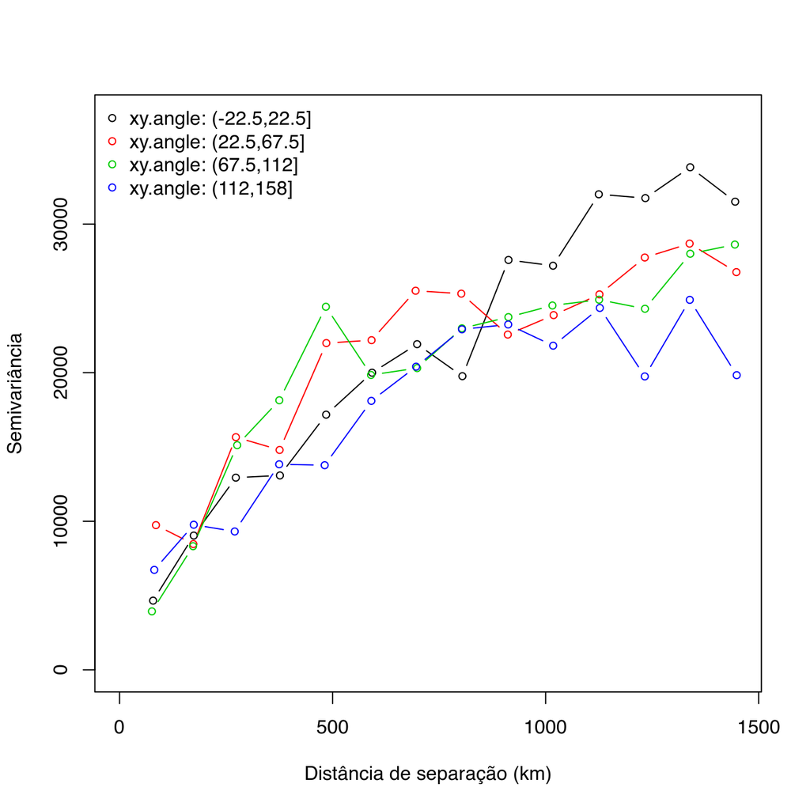

Figure 2.1: Variograma direcional dos resíduos do modelo linear do conteúdo de areia na camada superficial do solo.

```r
limites <- seq(0, 1500, length.out = 15)
residuals(lm_fit) %>%
  georob::sample.variogram(
    locations = pontos400in@coords, lag.dist.def = limites,
    xy.angle.def = c(0, 22.5, 67.5, 112.5, 157.5, 180)) %>%
  plot(type = "b", ylab = 'Semivariância', xlab = 'Distância de separação (km)')
```

```r
vario <-
  residuals(lm_fit) %>%
  georob::sample.variogram(
    locations = pontos400in@coords, lag.dist.def = limites)
vario_fit <-
  georob::fit.variogram.model(
  vario, variogram.model = 'RMexp', param = c(variance = 20000, nugget = 2000, scale = 500),
  weighting.method = "cressie", method = "BFGS")
```

[output not shown]

```r
reml_fit <- georob::georob(
  areia_ ~ um + geo, pontos400in, locations = ~ coord_x + coord_y, variogram.model = 'RMexp',
  param = c(variance = vario_fit$variogram.object[[1]]$param[['variance']],
            nugget = vario_fit$variogram.object[[1]]$param[['nugget']],
            scale = vario_fit$variogram.object[[1]]$param[['scale']]),
  tuning.psi = 1000, control = georob::control.georob(initial.fixef = 'lm'))
summary(reml_fit)
```

```
##
## Call:georob::georob(formula = areia_ ~ um + geo, data = pontos400in,
##     locations = ~coord_x + coord_y, variogram.model = "RMexp",
##     param = c(variance = vario_fit$variogram.object[[1]]$param[["variance"]],
##         nugget = vario_fit$variogram.object[[1]]$param[["nugget"]],
##         scale = vario_fit$variogram.object[[1]]$param[["scale"]]),
##     tuning.psi = 1000, control = georob::control.georob(initial.fixef = "lm"))
##
## Tuning constant:  1000
##
## Convergence in 13 function and 8 Jacobian/gradient evaluations
##
## Estimating equations (gradient)
##
##                                  eta         scale
##   Gradient           : -2.498554e-02 -1.454839e-01
##
## Maximized restricted log-likelihood: -2328.15
##
## Predicted latent variable (B):
##     Min      1Q  Median      3Q     Max
## -401.79  -82.80   10.03  128.73  427.66
##
## Residuals (epsilon):
##       Min        1Q    Median        3Q       Max
## -9.332793 -1.331201 -0.004369  1.248425  8.968548
##
## Standardized residuals:
##       Min        1Q    Median        3Q       Max
## -3.440757 -0.530451 -0.002582  0.479414  3.028140
##
##
## Gaussian REML estimates
##
## Variogram:  RMexp
##                 Estimate     Lower    Upper
## variance       2.710e+04 2.139e+04  34316.7
## snugget(fixed) 0.000e+00        NA       NA
## nugget         3.277e+02 1.511e-01 710529.6
## scale          1.966e+02 1.342e+02    287.8
```

[output cut: 21 more lines]

```
## umNeossolo Litólico                          0.7053
## umNeossolo Litólico - Neossolo Regolítico   0.3003
## umNeossolo Regolítico                        0.1385
## umNeossolo Regolítico                       0.1605
## umPlanossolo Háplico                         0.1246
## geobotucatu                                4.06e-08 ***
## geocaturrita                               4.85e-06 ***
## georiolito                                 8.85e-07 ***
## ---
## Signif. codes:  0 '***' 0.001 '**' 0.01 '*' 0.05 '.' 0.1 ' ' 1
##
## Residual standard error (sqrt(nugget)): 18.1
##
## Robustness weights:
##  All 376 weights are ~= 1.
```

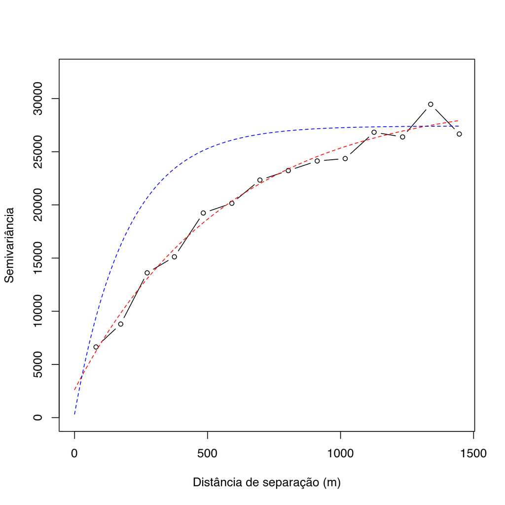

Figure 2.2: Variograma amostral (preto) dos resíduos do modelo linear do conteúdo de areia na camada superficial do solo e a função exponencial (vermelho) a ele ajustada.

```r
plot(vario, type = "b", xlab = 'Distância de separação (m)', ylab = 'Semivariância')
lines(vario_fit, col = "red", lty = 'dashed')
lines(reml_fit, col = "blue", lty = 'dashed')
```

```r
grid <- sp::spsample(pedologia25, 10000, type = 'regular')
grid <-
  sp::SpatialPointsDataFrame(
    coords = grid@coords,
    data = data.frame(
      um = sp::over(grid, pedologia25) %>% unlist(),
      geo = sp::over(grid, geologia50) %>% unlist()),
    proj4string = grid@proj4string)
str(grid)
```

```
## Formal class 'SpatialPointsDataFrame' [package "sp"] with 5 slots
##   ..@ data       :'data.frame':  10005 obs. of  2 variables:
##   .. ..$ um : Factor w/ 9 levels "Argissolo Bruno-Acinzentado",..: 1 1 1 1 1 9 9 9 9 1 ...
##   .. ..$ geo: Factor w/ 4 levels "basalto","botucatu",..: 3 3 3 3 3 3 3 3 3 3 ...
##   ..@ coords.nrs : num(0)
##   ..@ coords     : num [1:10005, 1:2] 229605 229649 229694 229738 229782 ...
##   .. ..- attr(*, "dimnames")=List of 2
##   .. .. ..$ : chr [1:10005] "um1" "um2" "um3" "um4" ...
##   .. .. ..$ : chr [1:2] "x1" "x2"
##   ..@ bbox       : num [1:2, 1:2] 226693 6715777 231856 6721689
##   .. ..- attr(*, "dimnames")=List of 2
##   .. .. ..$ : chr [1:2] "x1" "x2"
##   .. .. ..$ : chr [1:2] "min" "max"
##   ..@ proj4string:Formal class 'CRS' [package "sp"] with 1 slot
##   .. .. ..@ projargs: chr "+proj=utm +zone=22 +south +ellps=WGS84 +datum=WGS84 +units=m +no_defs +towgs84=0,0,0"
```

```r
colnames(grid@coords) <- colnames(pontos400in@coords)
pred_ponto <- predict(reml_fit, newdata = grid, control = georob::control.predict.georob(extended.output = TRUE))
sp::gridded(pred_ponto) <- TRUE
str(pred_ponto)
```

[output not shown]

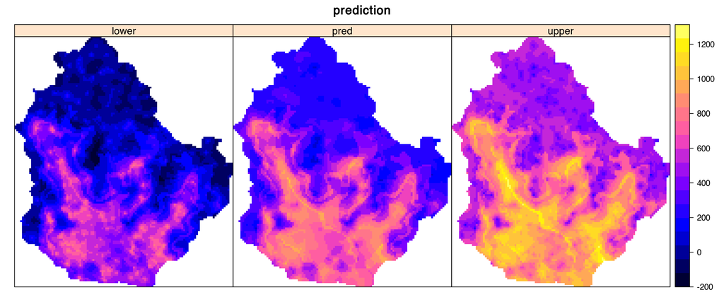

```r
at <- pred_ponto@data[, c("pred", "lower", "upper")] %>% range()
at <- seq(at[1], at[2], length.out = 20)
sp::spplot(pred_ponto, zcol = c("lower", "pred", "upper"), at = at, main = "prediction")
```

```r
validacao <- georob::cv(reml_fit)
```

```
##   for factor ' um ' some levels are missing in some calibration set(s),
##    respective factors are treated as offset terms in model
```

```r
summary(validacao)
```

```
##
## Statistics of cross-validation prediction errors
##       me      mede      rmse      made       qne      msse    medsse
##  14.6560    9.9873  153.0066  133.5758  145.5232    0.9352    0.3223
##     crps
##  86.2042
```

```r
1 - sum((validacao$pred$data - validacao$pred$pred)^2) / sum((validacao$pred$data - mean(validacao$pred$data))^2)
```

```
## [1] 0.6527338
```

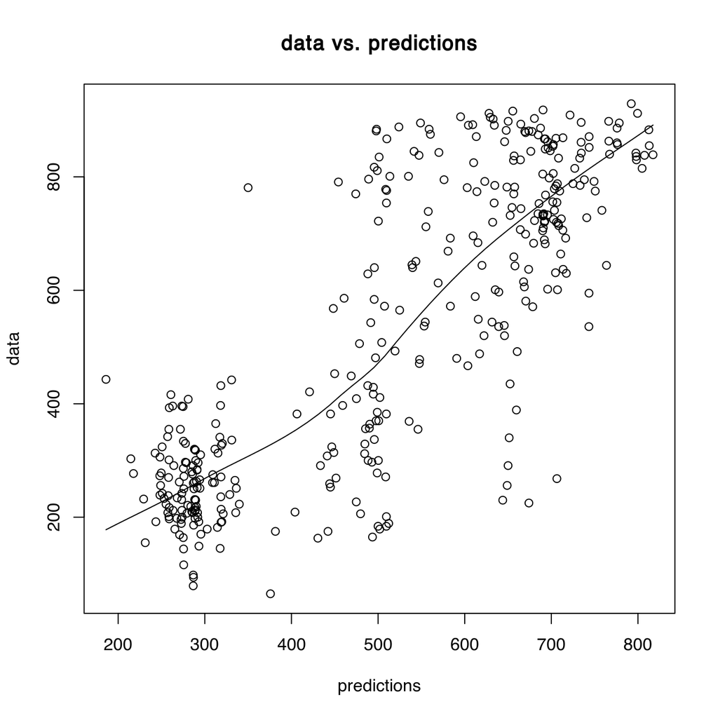

```r
plot(validacao)
```